# Module 4 Pair Quiz

Gian Carlo Fernandez, Iris Salangad

# Individual Quiz

## Question 1

### An article in the Journal of Sound and Vibration *[“Measurement of Noise-Evoked Blood Pressure by Means of Averaging Method: Relation between Blood Pressure Rise and PSL” (1991, Vol. 151(3), pp. 383-394)]* described a study investigating the relationship between noise exposure and hypertension. The following data are representative of those reported in the article.

| y | 1 | 0 | 1 | 2 | 5 | 1 | 4 | 6 | 2 | 3 | 5 | 4 | 6 | 8 | 4 | 5 | 7 | 9 | 7 | 6 |
| --- | --- | --- | --- | --- | --- | --- | --- | --- | --- | --- | --- | --- | --- | --- | --- | --- | --- | --- | --- | --- |
| x | 60 | 63 | 65 | 70 | 70 | 70 | 80 | 90 | 80 | 80 | 85 | 89 | 90 | 90 | 90 | 90 | 94 | 100 | 100 | 100 |

#### **A. Draw a scatter diagram of y (blood pressure rise in millimeters of mercury) versus x (sound pressure level in decibels). Does a simple linear regression seem reasonable in this situation?**

**In drawing scatter plots from this data, we’ll use R:**

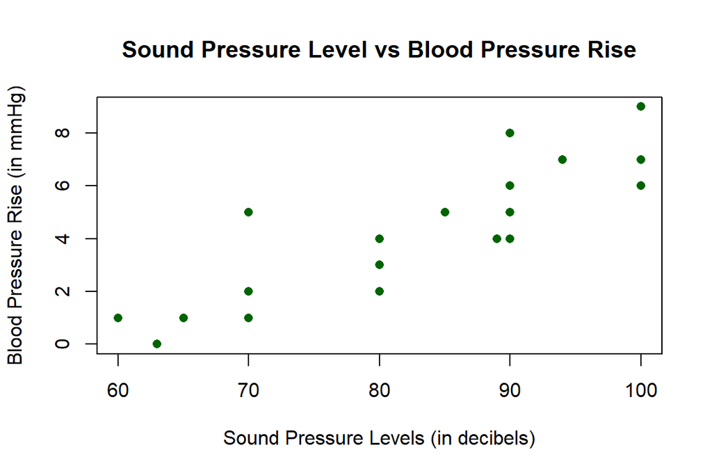

Graph 1. A Scatter Plot between **x** (*Sound Pressure Levels*) and **y** (*Blood Pressure Rise*)

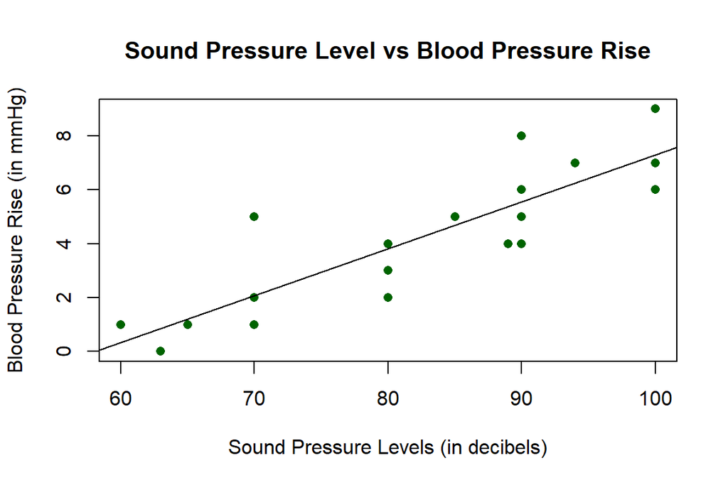

Graph 2. Also the Scatter Plot between **x** (*Sound Pressure Levels*) and **y** (*Blood Pressure Rise*) with a linear regression model calculated by **R**.

Notice that the scatter plot and the linear regression model shows correspondence in slope and points. The relationship of Sound Pressure level (x) and the Blood Pressure Rise (y) displayed somehow the same results between the two graphing system. It is in this sense where we can conclude that a linear progression model **is reasonable** in this situation as it fits accordingly with the scatter plot data.

#### **B. Fit the simple linear regression model using least squares. Find an estimate of $\sigma^2$.**

**Least Squares Method:**

$$n = 20$$
$$\sum_{i = 1}^{20}X_i = 1,656 \hspace{20pt} \sum_{i = 1}^{20}Y_i = 86$$

$$\overline{x} = 82.8 \hspace{50pt} \overline{y} = 4.3$$

$$\sum_{i = 1}^{20}X^2_i = 140,176 \hspace{20pt} \sum_{i = 1}^{20}Y^2_i = 494$$

$$\sum_{i = 1}^{20}X_iY_i = 7,654$$

We then calculate $S_{xx}$ and $S_{xy}$.

##### Solving for $S_{xx}$

$$\sum_{i = 1}^{n}(X_i - \overline{x})^2 = \sum_{i=1}^{n}X_i^2 - \frac{(\sum_{i=1}^{n}X_i)^2}{n}$$
$$= \sum_{i=1}^{20}X_i^2 - \frac{(\sum_{i=1}^{20}X_i)^2}{20}$$
$$= 140,176 - \frac{2,742,336}{20}$$
$$= 140,176 - 137,116.8
\\
= 3,059.2$$

##### Solving for $S_{xy}$

$$\sum_{i=1}^{n}Y_i(X_i - \overline{x})^2 = \sum_{i=1}^{n}X_iY_i - \frac{(\sum_{i=1}^{n}X_i)(\sum_{i=1}^{n}Yi)}{n}$$
$$= \sum_{i=1}^{20}X_iY_i - \frac{(\sum_{i=1}^{20}X_i)(\sum_{i=1}^{20}Yi)}{20}$$
$$= 7,654 - \frac{(1,656)(86)}{20}$$
$$= 7,654 - 7,120.8
\\
=533.2$$

From this, we can get the **least slope and intercept** which are:

$$\hat{\beta} = \frac{S_{xy}}{S_{xx}}
\\
= \frac{533.2}{3,059.2}
\\
= 0.1742939331$$
$$\hat{\beta}_0 = \overline{y} - \hat{\beta}_1 \overline{x}
\\
= 4.3 - (0.1743)(82.8)
\\
= - 10.13153766$$

Using the **Least Squares Method**, the equation of the line that best fit the plot is:

$$y = 0.1743939331x - 10.13153766$$

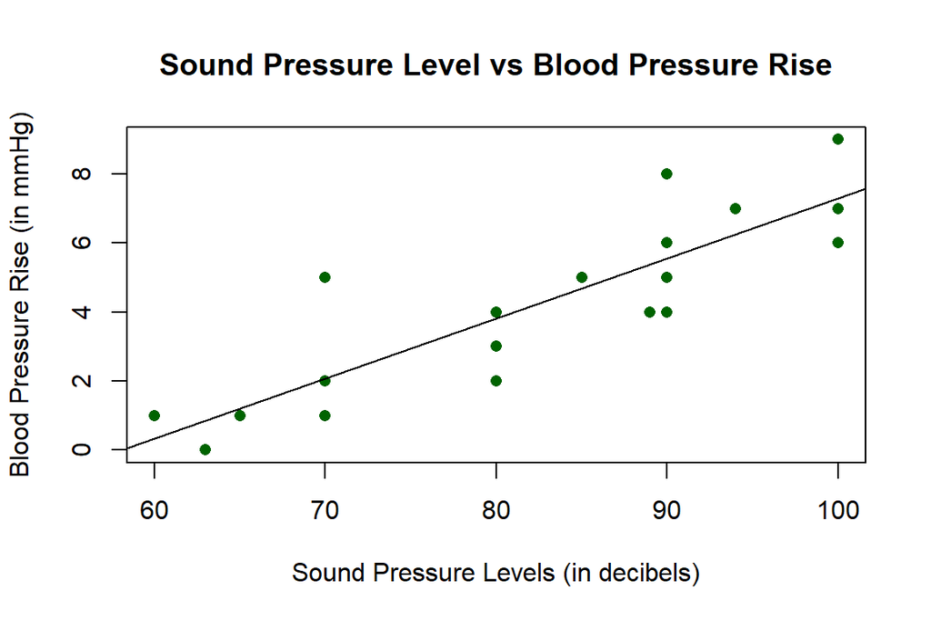

```r
y <- c(1, 0, 1, 2, 5, 1, 4, 6, 2, 3, 5, 4, 6, 8, 4, 5, 7, 9, 7, 6)

x <- c(60, 63, 65, 70, 70, 70, 80, 90, 80, 80, 85, 89, 90, 90, 90, 90, 94, 100, 100, 100)

plot(x,y, pch = 16, cex = 1, col = "dark green", main = "Sound Pressure Level vs Blood Pressure Rise", xlab = "Sound Pressure Levels (in decibels)", ylab = "Blood Pressure Rise (in mmHg)")

abline(- 10.13153766, 0.1743939331)
```

Graph 3. The Scatter Plot between **x** (*Sound Pressure Levels*) and **y** (*Blood Pressure Rise*) with the linear regression calculated using the **Least Squares Method**.

#### Calculating the Variance $\sigma^2$

```r
model <- lm(y~x)

deviance(model)
```

```
## [1] 31.26647
```

Since the sum of the squared of estimated errors is **31.26647**, we can substitute this to the equation:

$$\sigma^2 = \frac{SSE}{n-2}$$

$$= \frac{31.26647}{20-2}
\\
= 1.737026111$$

Therefore the $\sigma^2$ is equal to **1.737**.

#### **C. Find the predicted mean rise in blood pressure level associated with a sound pressure level of 85 decibels.**

Predicting the rise in blood pressure level associated with a sound pressure level is now easy to do since we calculated a linear regression of which we can use in the said process.

$$y = 0.1743939331x - 10.13153766$$
In this case, we simply just substitute **85 decibels** as x in the equation:

$$y = 0.1743939331x - 10.13153766$$

$$= 0.1743939331(85) - 10.13153766$$

$$= 14.82348431 - 10.13153766$$

$$= 4.691946654$$

Therefore, the blood pressure level will likely rise **4.69 mmHg** when the sound pressure level is **85 decibels**.

## Question 2

### An article in Optical Engineering *[“Operating Curve Extraction of a Correlator’s Filter”(2004, Vol.43, pp. 2775-2779)]* reported on the use of an optical correlator to perform an experiment by varying brightness and contrast. The resulting modulation is characterized by the useful range of gray levels. The data follow:

| Brightness (%) | 54 | 61 | 65 | 100 | 100 | 100 | 50 | 57 | 54 |
| --- | --- | --- | --- | --- | --- | --- | --- | --- | --- |
| Contrast (%) | 56 | 80 | 70 | 50 | 65 | 80 | 25 | 35 | 26 |
| Useful Range (ng) | 96 | 50 | 50 | 112 | 96 | 80 | 155 | 144 | 255 |

#### **A. Fit a multiple linear regression model to these data.**

First, we will be identifying the formula for Multiple Regression, which is:

$$\displaystyle y = \beta _0 + \beta _1x_1 + \beta _2x_2$$
Given that:

$Y =$ Useful Range

$x_1 =$ Brightness

$x_2 =$ Contrast

This is the set of data given above.

```
## # A tibble: 9 x 3
##   Brightness Contrast    UR
##        <dbl>    <dbl> <dbl>
## 1         54       56    96
## 2         61       80    50
## 3         65       70    50
## 4        100       50   112
## 5        100       65    96
## 6        100       80    80
## 7         50       25   155
## 8         57       35   144
## 9         54       26   255
```

```
##            Brightness Contrast    UR
## Brightness       1.00     0.50 -0.35
## Contrast         0.50     1.00 -0.86
## UR              -0.35    -0.86  1.00
```

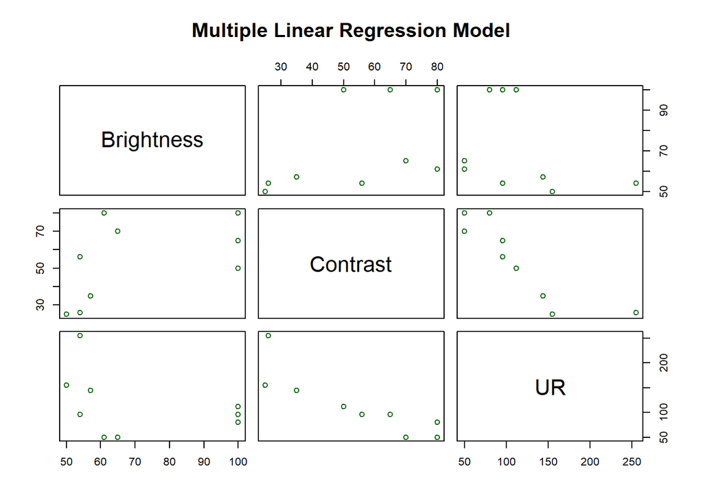

Figure 1. Multiple Linear Regression Model

```
##
## Call:
## lm(formula = UR ~ Brightness + Contrast, data = PAIR_QUIZ)
##
## Residuals:
##     Min      1Q  Median      3Q     Max
## -32.334 -20.090  -8.451   8.413  69.047
##
## Coefficients:
##             Estimate Std. Error t value Pr(>|t|)
## (Intercept) 238.5569    45.2285   5.274  0.00188 **
## Brightness    0.3339     0.6763   0.494  0.63904
## Contrast     -2.7167     0.6887  -3.945  0.00759 **
## ---
## Signif. codes:  0 '***' 0.001 '**' 0.01 '*' 0.05 '.' 0.1 ' ' 1
##
## Residual standard error: 36.35 on 6 degrees of freedom
## Multiple R-squared:  0.7557, Adjusted R-squared:  0.6742
## F-statistic: 9.278 on 2 and 6 DF,  p-value: 0.01459
```

According to the result above,

$\beta _0 = 238.5569$

$\beta _1 = 0.3339$

$\beta _2 = -2.7167$

Therefore, the **multiple linear regression model** is:

$$y = 238.5569 + 0.3339x_1 - 2.7167x_2$$

#### **B. Estimate $\sigma^2$.**

According to the table below,

```
##             Df Sum Sq Mean Sq F value  Pr(>F)
## Brightness   1   3960    3960   2.997 0.13412
## Contrast     1  20558   20558  15.559 0.00759 **
## Residuals    6   7928    1321
## ---
## Signif. codes:  0 '***' 0.001 '**' 0.01 '*' 0.05 '.' 0.1 ' ' 1
```

The $\sigma^2$ is equal to **1321.3**

#### **C. Compute the standard errors of the regression coefficients.**

Based on this table,

```r
#Importing Data
library(readxl)
PAIR_QUIZ <- read_excel("PAIR QUIZ.xlsx")


#Fitting Multiple Linear Regression
PAIR_QUIZ<-lm(UR ~ Brightness + Contrast, data=PAIR_QUIZ)
summary(PAIR_QUIZ)
```

```
##
## Call:
## lm(formula = UR ~ Brightness + Contrast, data = PAIR_QUIZ)
##
## Residuals:
##     Min      1Q  Median      3Q     Max
## -32.334 -20.090  -8.451   8.413  69.047
##
## Coefficients:
##             Estimate Std. Error t value Pr(>|t|)
## (Intercept) 238.5569    45.2285   5.274  0.00188 **
## Brightness    0.3339     0.6763   0.494  0.63904
## Contrast     -2.7167     0.6887  -3.945  0.00759 **
## ---
## Signif. codes:  0 '***' 0.001 '**' 0.01 '*' 0.05 '.' 0.1 ' ' 1
##
## Residual standard error: 36.35 on 6 degrees of freedom
## Multiple R-squared:  0.7557, Adjusted R-squared:  0.6742
## F-statistic: 9.278 on 2 and 6 DF,  p-value: 0.01459
```

The standard of errors of the regression coefficients are:

Std. Error for **Brightness** $= 0.6763$

Std. Error for **Contrast** $= 0.6887$

#### **D. Predict the useful range when the brightness=80 and contrast=75.**

Using the formula of the multiple regression model from the part A,

$$y = 238.5569 + 0.3339x_1 - 2.7167x_2$$

We can plug in the values of the brightness=80 and contrast=75: where

$X_1 = 80$ $X_2 = 75$

$$y = 238.5569 + 0.3339(80) - 2.7167(75)$$
$$y = 61.5164$$
The **value of the useful range** when the brightness = 80 and contrast = 75 is **61.5164**

#### **E. Test for significance of regression using $\alpha = 0.05$. What is the P-value for this?**

The hypothesis are:

$H_0 : \beta _1 = \beta _2 = ... = \beta _k = 0$

$H_1 : \beta _j \neq 0$

The formula for the test statistic:

$F_0 = \frac {SS_R / k}{SS_E / (n-p)} = \frac {MS_R}{MS_E}$

The **null hypothesis will be rejected** if $f_0$ > $f_{0.05,2,6}$

Using this table,

```r
#Importing Data
library(readxl)
PAIR_QUIZ <- read_excel("PAIR QUIZ.xlsx")
PAIR_QUIZ
```

```
## # A tibble: 9 x 3
##   Brightness Contrast    UR
##        <dbl>    <dbl> <dbl>
## 1         54       56    96
## 2         61       80    50
## 3         65       70    50
## 4        100       50   112
## 5        100       65    96
## 6        100       80    80
## 7         50       25   155
## 8         57       35   144
## 9         54       26   255
```

```r
#Fitting Multiple Linear Regression
PAIR_QUIZ<-lm(UR ~ Brightness + Contrast, data=PAIR_QUIZ)
summary(PAIR_QUIZ)
```

```
##
## Call:
## lm(formula = UR ~ Brightness + Contrast, data = PAIR_QUIZ)
##
## Residuals:
##     Min      1Q  Median      3Q     Max
## -32.334 -20.090  -8.451   8.413  69.047
##
## Coefficients:
##             Estimate Std. Error t value Pr(>|t|)
## (Intercept) 238.5569    45.2285   5.274  0.00188 **
## Brightness    0.3339     0.6763   0.494  0.63904
## Contrast     -2.7167     0.6887  -3.945  0.00759 **
## ---
## Signif. codes:  0 '***' 0.001 '**' 0.01 '*' 0.05 '.' 0.1 ' ' 1
##
## Residual standard error: 36.35 on 6 degrees of freedom
## Multiple R-squared:  0.7557, Adjusted R-squared:  0.6742
## F-statistic: 9.278 on 2 and 6 DF,  p-value: 0.01459
```

The **p-value** is equal to 0.01459.

The $f_0$, or the f-statistic, is equal to 9.278 and the $f_{0.05,2,6}$, or the f-critical value with 2 and 6 as degree of freedoms, is equal to $5.1432528$.

Since $9.278 > 5.1432528$, we can say that the null hypothesis is rejected.

#### **F. Construct a $t$-test on each regression coefficient. What conclusions can you draw about the variables in this model? Use $\alpha=0.05$**.

The hypotheses are:

$H_0 : \beta _0 = 0 , \beta _1 = 0 , \beta _2 = 0$

$H_1 : \beta _0 \neq 0 , \beta _1 \neq 0 , \beta _2 \neq 0$

Based on this table,

```r
#Importing Data
library(readxl)
PAIR_QUIZ <- read_excel("PAIR QUIZ.xlsx")

#Fitting Multiple Linear Regression
PAIR_QUIZ<-lm(UR ~ Brightness + Contrast, data=PAIR_QUIZ)
summary(PAIR_QUIZ)
```

```
##
## Call:
## lm(formula = UR ~ Brightness + Contrast, data = PAIR_QUIZ)
##
## Residuals:
##     Min      1Q  Median      3Q     Max
## -32.334 -20.090  -8.451   8.413  69.047
##
## Coefficients:
##             Estimate Std. Error t value Pr(>|t|)
## (Intercept) 238.5569    45.2285   5.274  0.00188 **
## Brightness    0.3339     0.6763   0.494  0.63904
## Contrast     -2.7167     0.6887  -3.945  0.00759 **
## ---
## Signif. codes:  0 '***' 0.001 '**' 0.01 '*' 0.05 '.' 0.1 ' ' 1
##
## Residual standard error: 36.35 on 6 degrees of freedom
## Multiple R-squared:  0.7557, Adjusted R-squared:  0.6742
## F-statistic: 9.278 on 2 and 6 DF,  p-value: 0.01459
```

the test statistics are:

$t_0, _{\beta0} = 5.274$

$t_0, _{\beta1} = 0.494$

$t_0, _{\beta2} = -3.945$

$\beta_1$ : BRIGHTNESS

As $|t_0| < t _{0.025,6}$, we can say that we **fail to reject** the $H_0 : \beta_1 = 0$.

Therefore, the **brightness does not significantly contribute to the model.**

$\beta_2$ : CONTRAST

As $|t_0| > t _{a/2,n-p}$ , we can say that we **reject** the $H_0 : \beta_2 = 0$.

Therefore, the **contrast significantly contributes to the model.**

#### **References:**

https://www.youtube.com/watch?v=Uo2YflerjI4